# Programming for Business Analytics

Aadesh Gyanmothe

4/10/2022

#Introduction #I choose the “insurance” datset. This dataset primarily documents the various features of health insurance company members as well as the rates they now pay. I understood that insurance firms need to collect a greater premium than the amount provided to the insured individual in order to earn profit, thus determining how to charge different fees for different sorts of consumers is a significant issue for insurance businesses. my goal is to use the “insurance” dataset to investigate which habits and performance of insurance company members have a substantial impact on their rates, in order to assist insurance firms in developing the best pricing strategy.

#Required Libraries and Importing of the DataSet

```r
library(Hmisc)
```

```r
library(ggplot2)
library(ggthemes)
library(PerformanceAnalytics)
library(readr)
```

#Presentation of the data

```r
insurance <- read_csv("insurance.csv")
```

#Presentation and Description of the data

```r
summary(insurance)
```

```
##       age            sex                 bmi           children
##  Min.   :18.00   Length:1338        Min.   :15.96   Min.   :0.000
##  1st Qu.:27.00   Class :character   1st Qu.:26.30   1st Qu.:0.000
##  Median :39.00   Mode  :character   Median :30.40   Median :1.000
##  Mean   :39.21                      Mean   :30.66   Mean   :1.095
##  3rd Qu.:51.00                      3rd Qu.:34.69   3rd Qu.:2.000
##  Max.   :64.00                      Max.   :53.13   Max.   :5.000
##     smoker             region             charges
##  Length:1338        Length:1338        Min.   : 1122
##  Class :character   Class :character   1st Qu.: 4740
##  Mode  :character   Mode  :character   Median : 9382
##                                        Mean   :13270
##                                        3rd Qu.:16640
##                                        Max.   :63770
```

#Observations from the dataset:

#There are 7 variables, 1338 observations in this dataset, and there is no any missing values.

#Age: shows insurance contractor age; from 18 to 64 years old; the average age is 39; continous variable.

#Sex: insurance contractor gender- including female and male; the proportions of them are almost evenly distributed; categorical variable.

#BMI: body mass index, a value calculated from a person’s mass (weight) and height; from 15.96 to 53.13; the average bmi is 30.66; continous variable.

#Children: numbers of children insurance contractor has; from 0 to 5; most contractors have no more than 2 children; continous variable.

#Smoker: shows whether the insurance contractor smoking or not; including yes and no; non-smokers are four times as likely as smokers; categorical variable.

#Region: shows the insurance contractor’s living area in the US; including four areas-northeast, southeast, southwest, northwest; the proportions of them are almost evenly distributed; categorical variable.

#Charges: Expenses to be paid by insurance contractor as set by insurance company; from 1121 to 63770; the average charges is 13270; continous variable and predict value.

#Exploratory Data Analysis and Visualize

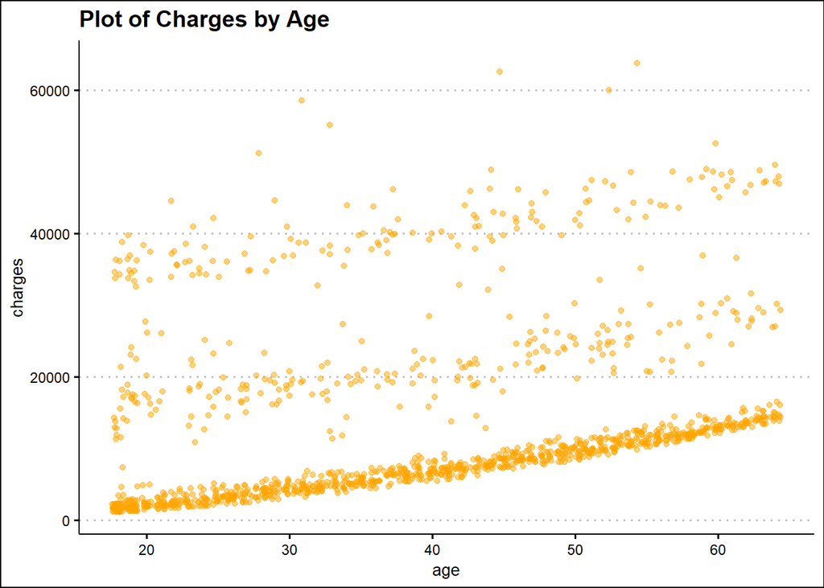

```r
age_charges <- ggplot(insurance, aes(age, charges)) +
  geom_jitter(color = "orange", alpha = 0.5) + theme_clean() + ggtitle("Plot of Charges by Age")
age_charges
```

#As the age increases, the charges also increase accordingly. At the same time, it is seen that there are three clear linear positive correlation lines in this plot, but mainly focus on the bottom line.

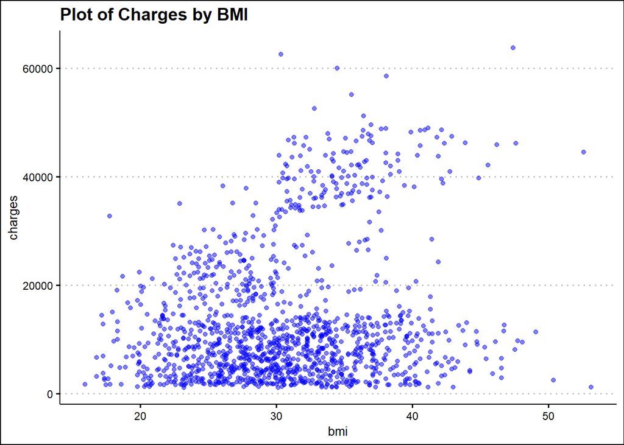

```r
BMI_charges <- ggplot(insurance, aes(bmi, charges)) +
  geom_jitter(color = "blue", alpha = 0.5) + theme_clean() + ggtitle("Plot of Charges by BMI")
BMI_charges
```

#The trend was not as clear as age, but overall charges also increased with BMI.

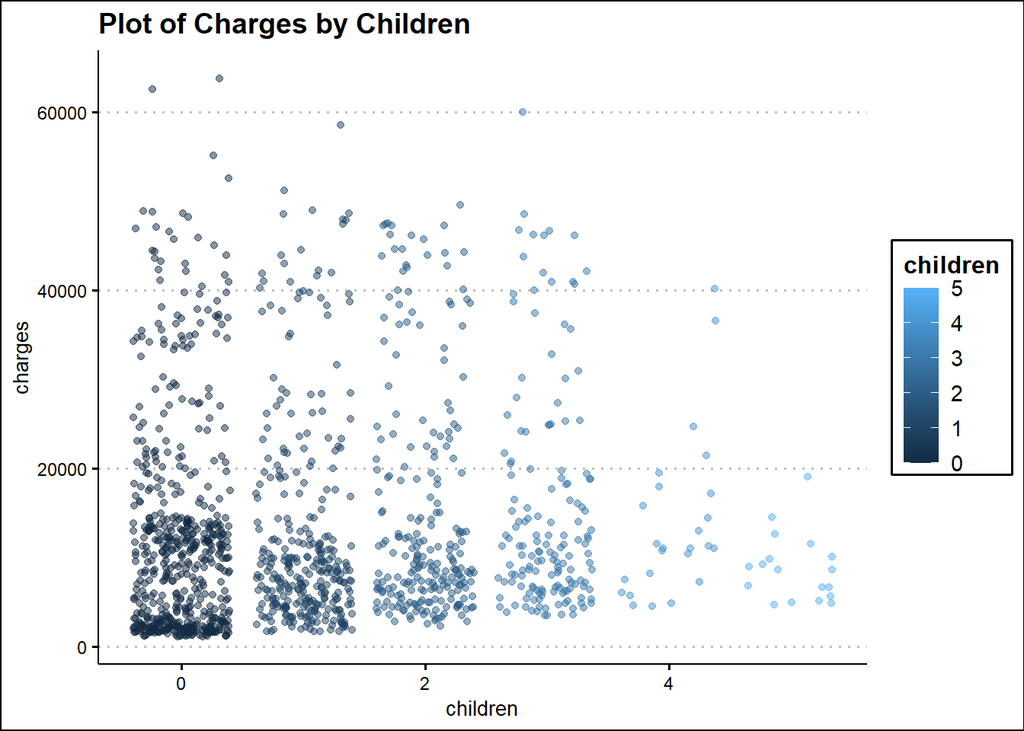

```r
children_charges <- ggplot(insurance, aes(children, charges)) +
  geom_jitter(aes(color = children), alpha = 0.5) + theme_clean() + ggtitle("Plot of Charges by Children")
children_charges
```

#From this plot, we get that in families with the number of children from 0 to 5, the charges for clients with five children is significantly lower.

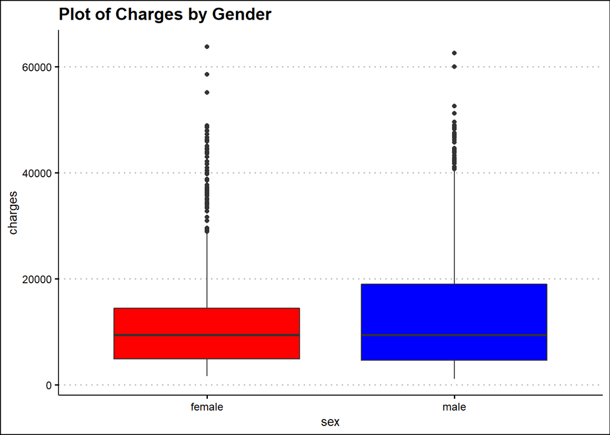

```r
gender_charges <- ggplot(insurance,aes(sex,charges)) + geom_boxplot(fill = c("red", "blue")) +
  theme_clean() + ggtitle("Plot of Charges by Gender")
gender_charges
```

#Charges do not differ much by gender.

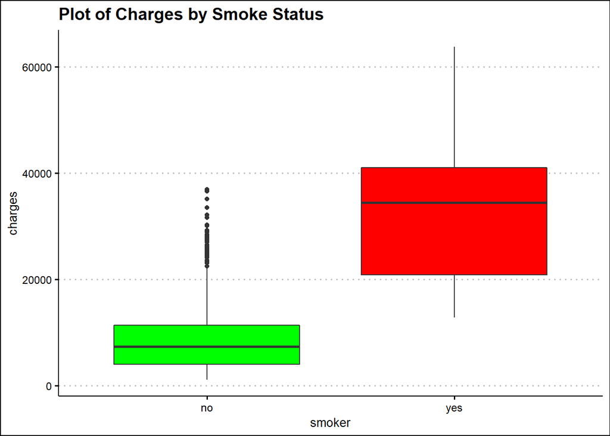

```r
smoker_charges <- ggplot(insurance,aes(smoker,charges)) + geom_boxplot(fill = c("green", "red")) +
  theme_clean() + ggtitle("Plot of Charges by Smoke Status")
smoker_charges
```

#The result was more charges for smokers than non-smokers.

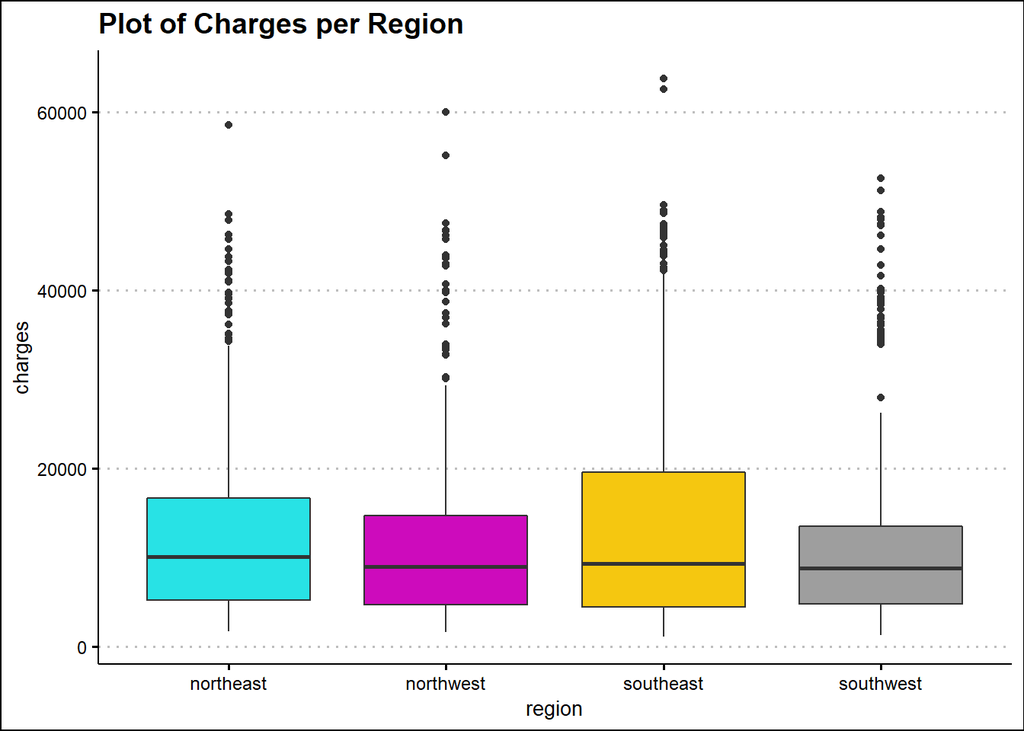

```r
region_charges <- ggplot(insurance,aes(region,charges)) + geom_boxplot(fill = c(5:8)) +
  theme_clean() + ggtitle("Plot of Charges per Region")
region_charges
```

#Regional differences have little impact on charges #Overall,by analyzing each of the above variables one by one, initially have the effect of age, BMI, smokers and number of children on charges.Now, I am going to run the chart.Correlation to get an overview of correlation among variables and between each variable and charges.

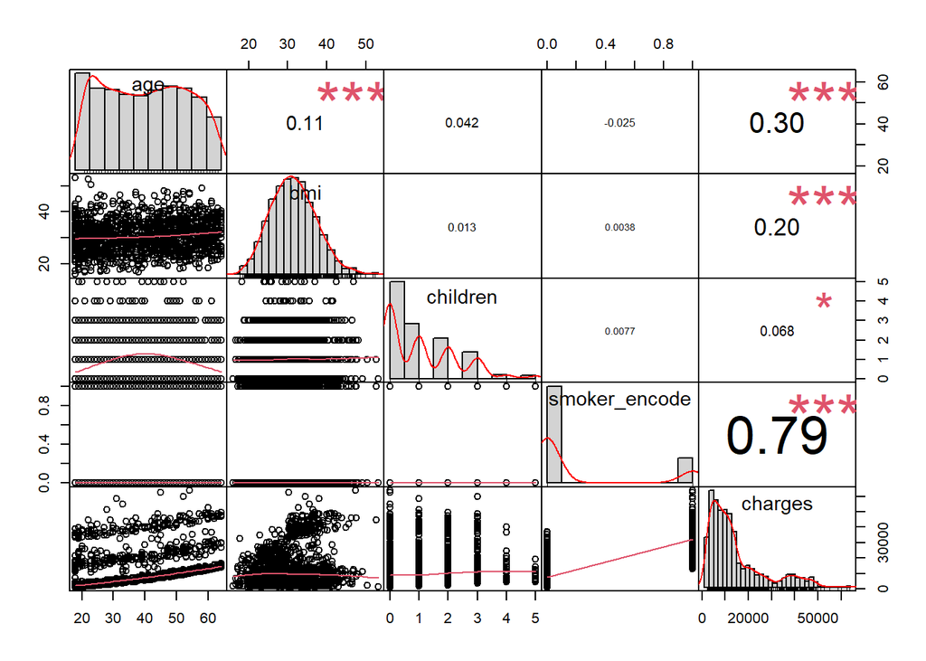

```r
insurance$smoker_encode <- ifelse(insurance$smoker == "yes",1,0)
df <- insurance[, c(1,3,4,8,7)]
chart.Correlation(df, histogram=TRUE, pch=19)
```

#From this plot, we can see that smoker has the highest correlation with charges. At the same time, there is little correlation between the variables.

#Linear Regression Model #splitting the data into train and test

```r
set.seed(1)
row.number <- sample(1:nrow(insurance), round(0.8*nrow(insurance)))
train = insurance[row.number,]
test = insurance[-row.number,]
dim(train)
```

```
## [1] 1070    8
```

```r
dim(test)
```

```
## [1] 268   8
```

#Running the first model (include all the variables)

```r
mod1 <- lm(charges ~ age + bmi + children + smoker + region + sex, train)
prediction1 <- predict(mod1,test)
residuals1 <- test$charges - prediction1
rmse1 <- sqrt(mean(residuals1^2))
summary(mod1)
```

```
##
## Call:
## lm(formula = charges ~ age + bmi + children + smoker + region +
##     sex, data = train)
##
## Residuals:
##      Min       1Q   Median       3Q      Max
## -11360.2  -2816.4   -982.6   1201.8  30283.9
##
## Coefficients:
##                  Estimate Std. Error t value Pr(>|t|)
## (Intercept)     -11555.38    1064.46 -10.856  < 2e-16 ***
## age                263.96      13.25  19.928  < 2e-16 ***
## bmi                310.74      31.11   9.987  < 2e-16 ***
## children           423.14     152.21   2.780  0.00553 **
## smokeryes        23404.30     457.83  51.120  < 2e-16 ***
## regionnorthwest   -133.07     522.73  -0.255  0.79911
## regionsoutheast   -814.44     521.66  -1.561  0.11876
## regionsouthwest   -658.05     528.93  -1.244  0.21373
## sexmale            -37.79     366.84  -0.103  0.91797
## ---
## Signif. codes:  0 '***' 0.001 '**' 0.01 '*' 0.05 '.' 0.1 ' ' 1
##
## Residual standard error: 5959 on 1061 degrees of freedom
## Multiple R-squared:  0.7498, Adjusted R-squared:  0.7479
## F-statistic: 397.4 on 8 and 1061 DF,  p-value: < 2.2e-16
```

```r
rmse1
```

```
## [1] 6492.856
```

#From the first model we built, firstly, we can see that F(397.4) is far greater than 1. It can be concluded that there is a relationship between variables and predictor. As per our our previous observations, Age, Bmi, Children and Smokers are the significant variables (have less p value) for charges.Then, based on the Adjusted r-squared, we got 0.7479, which is close to 1. It indicates that our first model explains the 74.79% of the variation of charges and hence a good fit.

#Running the second model (only include the significant variables)

```r
mod2<- lm(charges ~ age + bmi + children + smoker, train)
prediction2 <- predict(mod2, test)
residuals2 <- test$charges - prediction2
rmse2 <- sqrt(mean(residuals2^2))
summary(mod2)
```

```
##
## Call:
## lm(formula = charges ~ age + bmi + children + smoker, data = train)
##
## Residuals:
##      Min       1Q   Median       3Q      Max
## -11764.6  -2884.5   -958.9   1199.1  29876.5
##
## Coefficients:
##              Estimate Std. Error t value Pr(>|t|)
## (Intercept) -11578.30    1010.82 -11.454  < 2e-16 ***
## age            264.87      13.23  20.026  < 2e-16 ***
## bmi            296.29      29.78   9.951  < 2e-16 ***
## children       424.54     152.02   2.793  0.00532 **
## smokeryes    23380.04     453.89  51.511  < 2e-16 ***
## ---
## Signif. codes:  0 '***' 0.001 '**' 0.01 '*' 0.05 '.' 0.1 ' ' 1
##
## Residual standard error: 5957 on 1065 degrees of freedom
## Multiple R-squared:  0.749,  Adjusted R-squared:  0.748
## F-statistic: 794.4 on 4 and 1065 DF,  p-value: < 2.2e-16
```

```r
rmse2
```

```
## [1] 6521.041
```

#From this new model, we can see that F(794.4) is far greater than 1 and this value is more than the F value(397.4) of the previous model. It makes sense, because we removed the less significant feature.The relationship between the number of children and charges is relatively insignificant in this new model compared to other variables, but Children still has a low P value.

#For the Adjusted r-squared of model 2, we can see it a little bit higher but also quite similar to the first model’s.

#Then compare the RMSE of the two models, we got that RMSE2(6521.041) is higher than RMSE1(6492.856). It means model2 has a relatively larger gap between the predicted and observed values.

#Overall, I would say there is no big differences between the above models, and we are going to take model 2 as our final regression model since it only has four observed values, which is more easier for us to execute following predict work.

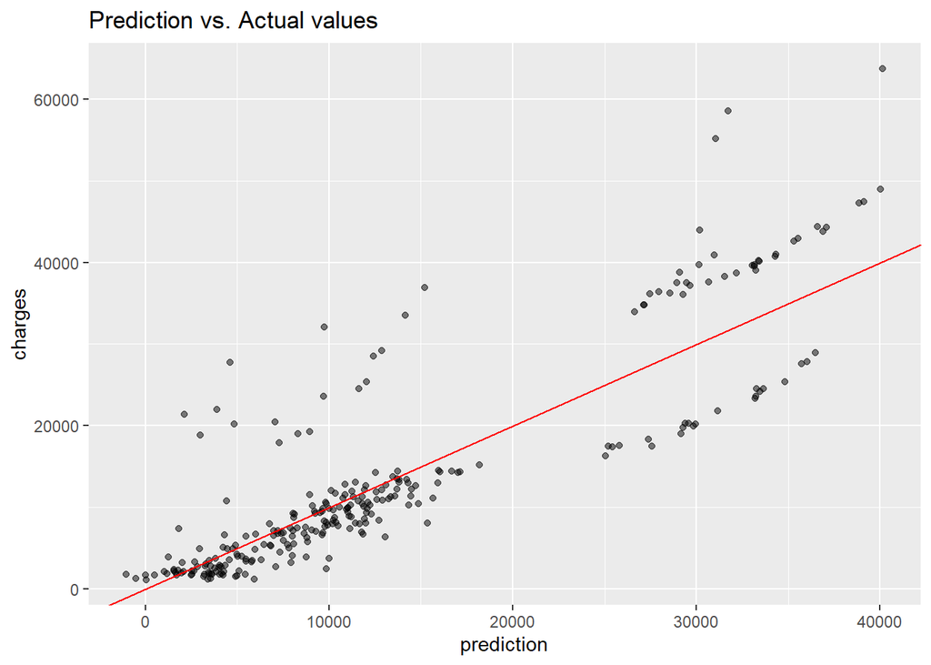

```r
prediction<- predict(mod2, test)
ggplot(test, aes(x = prediction, y = charges)) + geom_point(color = "black", alpha = 0.5) + geom_abline(color = "red") +
  ggtitle("Prediction vs. Actual values")
```

#Prediction Function

#Based on the model2, the equation will be like: charges = -11578.30 + 264.87age + 296.29bmi + 424.54children + 23380.04smokeryes.

```r
predict_charge <- function(age, bmi, children, smoker){
  if(smoker == "yes"){
    result = -11578.30 + (264.87*age) + (296.29*bmi) + (424.54*children) + 23380.04
  } else if(smoker == "no") {
    result = -11578.30 + (264.87*age) + (296.29*bmi) + (424.54*children)
  }
  return(result)
}
```

#Tom:35 years old; bmi is 34.4; 0 child; smoke.

#We can get his charges supposed to be:

```r
predict_charge(35,34.4,0,"yes")
```

```
## [1] 31264.57
```